# Prosper_loan_project_II slides

## Part II - Key Insight On the Prosper Loan Analysis

## By David Abiose

## Investigation Overview

> In this inquiry, we will investigate crucial factors that influence loans, their distribution, and their effects on loan amounts.

## Dataset Overview

> The prosper loan data set contains 113,937 loans with 81 variables on each loan, including loan amount, borrower rate (or interest rate), current loan status, borrower income, and many others. After the dataset underwent various evaluations, we decided to clean it up and make certain adjustments and modifications to improve our study.

## Distribution of Borrowers Monthly Income

The StatedMonthlyIncome exhibits a normal distribution when plotted on a log-scale, with the numbers forming a symmetrical shape. With the peak lying between $3,000 and $5,000 per month, StatedMonthlyIncome appears to be unimodal.

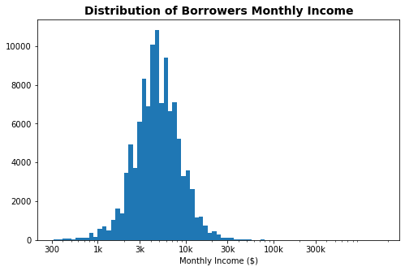

## Distribution of Debt-To-Income Ratio

The modest bin size for DebtToIncomeRatio proves to be extremely instructive. Its distribution is right-skewed, with most of the loans falling into the low debt-to-income ratio range and few falling into the high debt-to-income range.

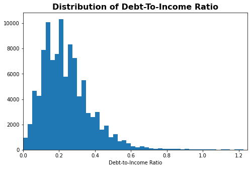

## Distribution of APR & Distribution of Interest Rate

Both variables appear to have a distribution shape that is almost symmetical in character, with a spike between the range of 0.3 and 0.4 of the rates appearing to indicate the modal value of both variables. In comparison to BorrowerIR, BorrowerAPR typically has a greater modal value.

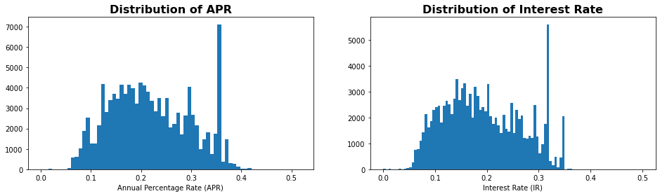

## Proportions of Loan status

The majority of loans granted, or 49.3%, are in the "current loan-status," with "others," which represents closed loans, coming in second with 48.7%. The lowest percentage of loans authorized is for "FinalPaymentInProgress" loans, which is 0.2%. Note: Others here are loan status that are (Completed, Chargedoff, Defaulted, Cancelled)

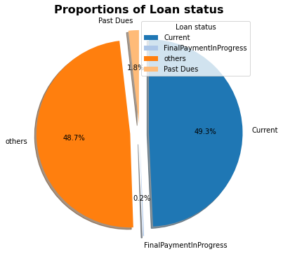

## Absolute Frequency of Prosper Risk Levels & Prosper Ratings

It is clear from the countplots that the highest loan distribution belongs to the rating "4.0-C," and the level of risk connected to the greatest loan count is "medium high."

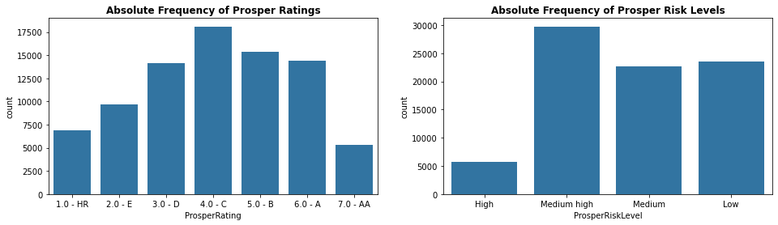

## Relative Frequency of Employment status

Employed individuals make up a greater proportion of loan borrowers, while retirees make up the smallest proportion.

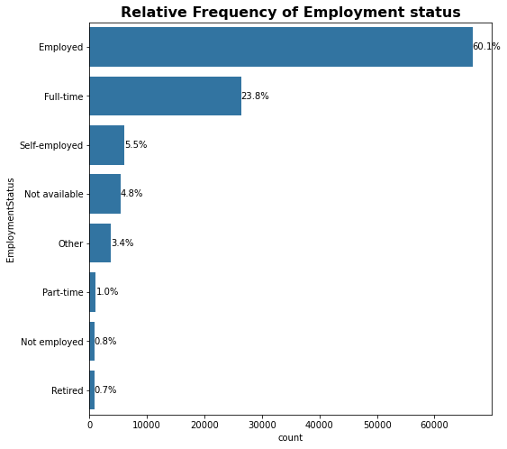

## Relative Frequency of Listing Category

The majority of borrowers choose to use the loan for debt consolidation when choosing their ListingCategory.

- Debt consolidation: it refers to the act of taking out a new loan to pay off other liabilities and consumer debts.

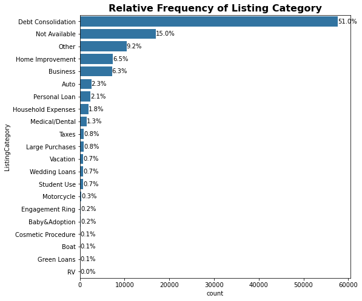

## Proportion Of Loan Terms

It is clear from the donut plot that the loan term that is most frequently offered is 36 months, accounting for 77.1% of all loan counts, and the period with the lowest proportion is 12 months.

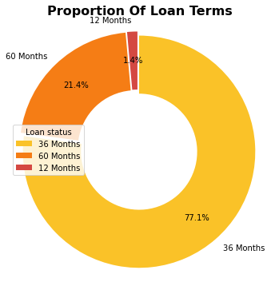

## Correlation OF All Numeric Key Variables

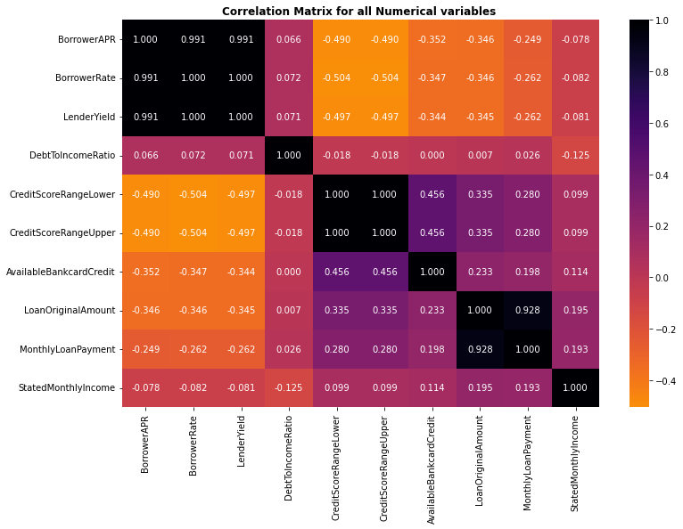

## Risk Level and Terms By Loan Amount & APR

It's interesting to see that the two important numeric variables appear to have some meaningful correlations with the category variables. The loan amounts awarded to borrowers with the highest risk levels are remarkably small. This relates to a common scenario in which lenders won't be prepared to offer greater loans when they believe the risk to be very high.

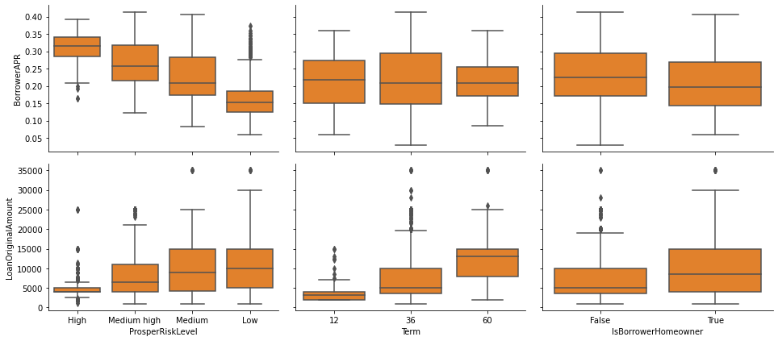

## Trends in Average Loan Amount

The average loan amount issued to the borrower decreased from 2007 to 2009, as seen by the line plot, which shows the trends of average loan initial amount for each year starting in 2007. In 2009, the trend reached its lowest point and The reason for this is because prosper closed in 2009 to complete the SEC filing procedure and reopened on July 1st, 2009, following SEC registration. [Prosper 2009](https://onlinemoneyfordads.com/is-prosper-a-scam-get-the-answers-in-my-review/#:~:text=Prosper%20had%20shut%20down%20in%202009%20to%20go,scale%3B%20so%20Prosper%E2%80%99s%20rank%20is%20an%20excellent%20rating).

The average loan amount issued to borrowers increased steadily starting in 2010 and continued through 2014, according to data.

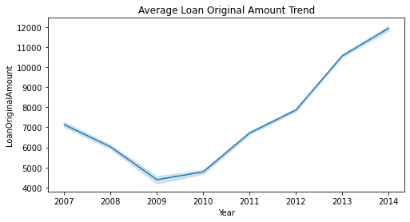

## Loan Amount By Risk level and Rating

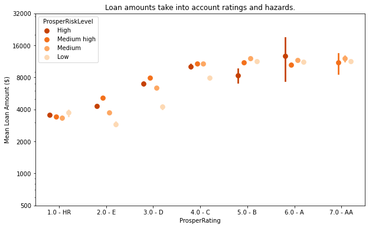